# Image Compression Results

# Code for Image Compression

```r
library(readr)
library(tidyverse)

image1 <- read.csv("~/SDS365/image_compression/HW2imagefiles/image1.csv")
image2 <- read.csv("~/SDS365/image_compression/HW2imagefiles/image2.csv")
image3 <- read.csv("~/SDS365/image_compression/HW2imagefiles/image3.csv")
image4 <- read.csv("~/SDS365/image_compression/HW2imagefiles/image4.csv")

image1 <- data.matrix(image1)
image2 <- data.matrix(image2)
image3 <- data.matrix(image3)
image4 <- data.matrix(image4)

image_error <- function(M, M_k){
  # Frobenius norm of difference X - X_k
  error_k <- norm(M - M_k, type = "F")
  return (error_k)
}

compress_image <- function(k, M){
  # Function takes n x p matrix M and integer k
  # Returns: rank k approximation of image matrix using PCA
  # and, error of rank k approximation w/Frobenius norm

  # Cross product of M
  V <- crossprod(M, M)

  # Eigendecomposition of V
  eigendecomp_V <- eigen(V)

  # Eigenvector matrix
  U <- eigendecomp_V$vectors

  # PC Score matrix
  Z <- M %*% U

  # Initialize rank approx
  M_k <- matrix(0, nrow = nrow(M), ncol = ncol(M))

  # Rank approximation
  for (i in 1:k){
    M_k <- M_k + (Z[, i] %o% U[, i])
  }

  # Frobenius norm of difference M - M_k
  error_k <- image_error(M, M_k)

  return (list(M_k = M_k, error_k = error_k, U = U, Z = Z))
}

error_k <- function(M, k){

  # Cross product of M
  V <- crossprod(M, M)

  # Eigendecomposition of V
  eigendecomp_V <- eigen(V)

  # Eigenvector matrix
  U <- eigendecomp_V$vectors

  # PC Score matrix
  Z <- M %*% U

  # Initialize rank approx
  M_k <- matrix(0, nrow = nrow(M), ncol = ncol(M))

  errors <- numeric(k)

  for (i in 1:k){
    M_k <- M_k + (Z[, i] %o% U[, i])
    errors[i] <- image_error(M, M_k)
  }

  error_data <- data.frame(k = 1:k,
                           error = errors)

  return (error_data)
}
```

# Image 1

## Original image

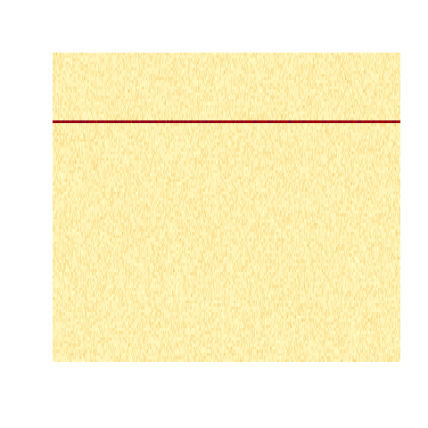

## Image Approximations

### k = 1

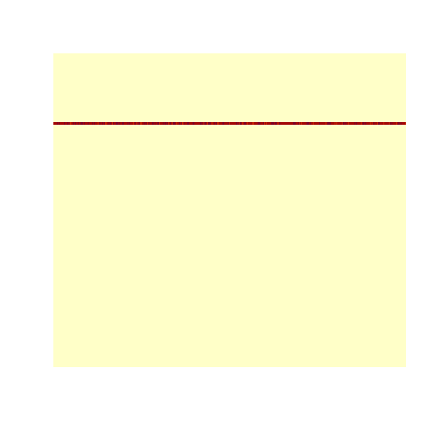

### k = 2

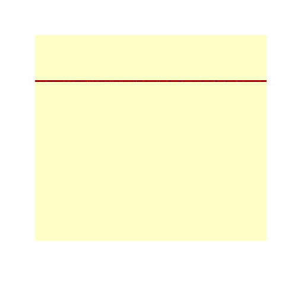

### k = 3

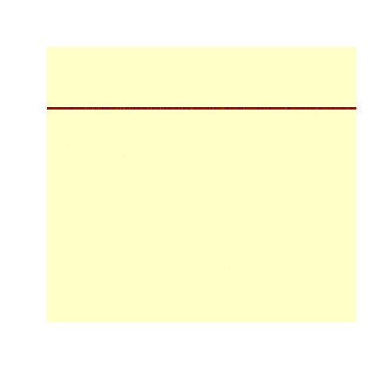

### k = 4

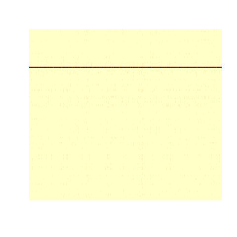

### k = 5

[figure not shown]

### k = 6

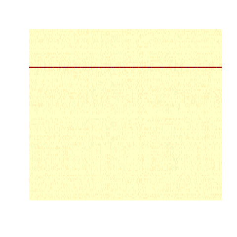

### k = 7

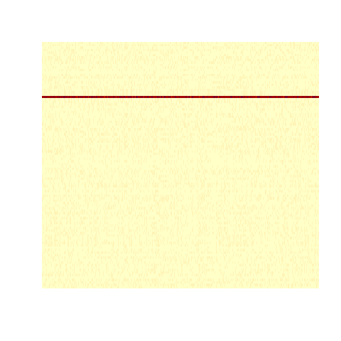

### k = 8

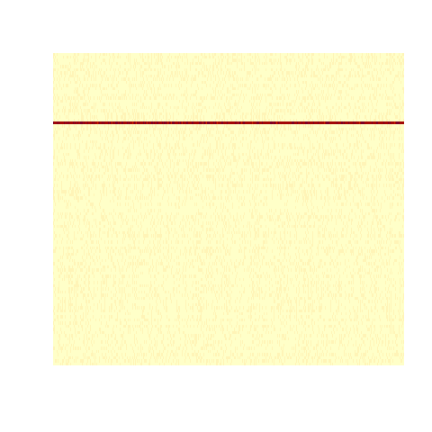

### k = 9

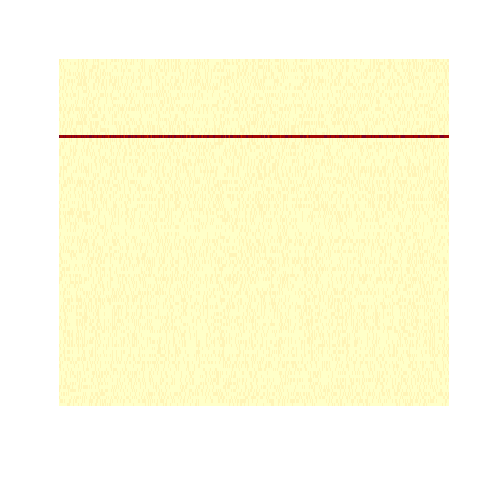

### k = 10

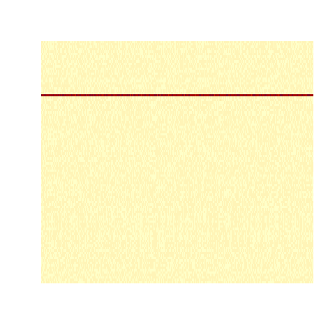

The image approximation looks sufficient at k = 5, because at that point it captures more of the noise present in the original image.

## K vs. Error plot

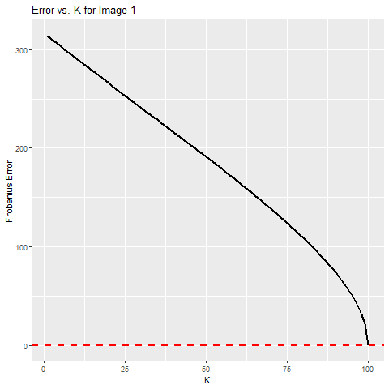

## 1st Eigenvector and PC Score plots

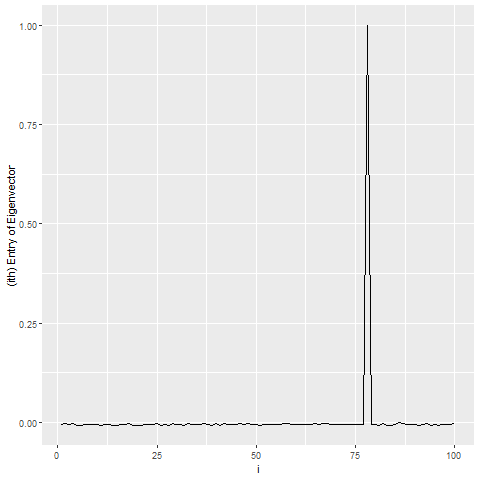

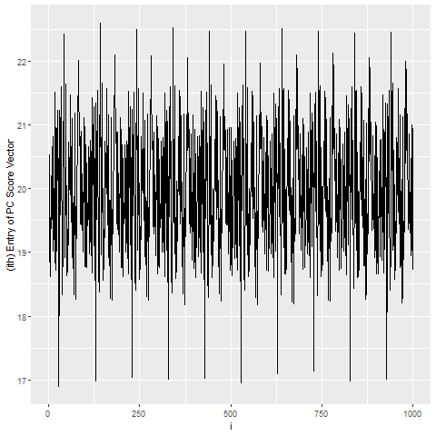

The eigenvector plot shows a massive spike at around the 77th index, which may correspond with the pixels forming the single line across the image. The PC score plot displays a consistent pattern of upward and downward spikes, which suggests a consistent level of noise across the image.

# Image 2

## Image Approximations

### k = 1

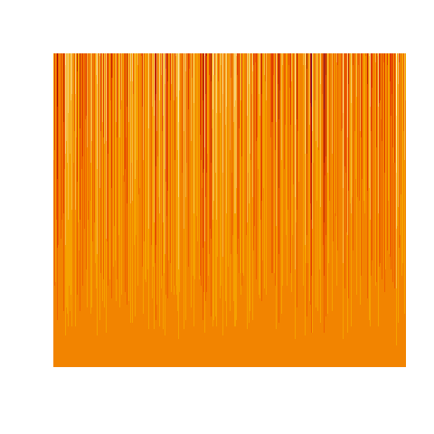

## K vs. Error plot

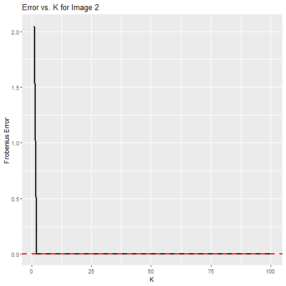

## 1st Eigenvector and PC Score plots

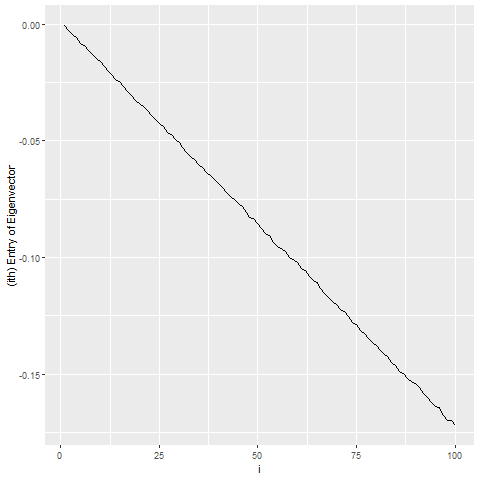

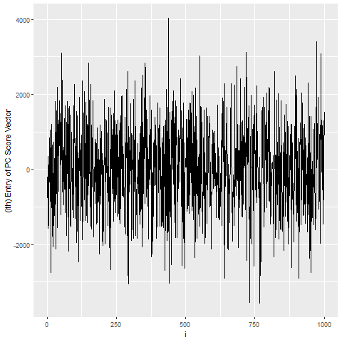

The eigenvector plot is a linear, downward sloping line, suggesting that the weights forming the first PC are decreasing with every next variable. This makes sense, because the bottom of the image has much less details compared to the upper part of the image. The PC score plot shows a similar oscillating pattern, but several spikes appear incongruent with the rest of the plot which is an indication of the inconsistency of noise in the image.

# Image 3

## Original image

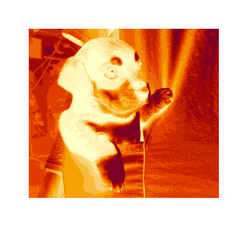

## Image Approximations

### k = 1

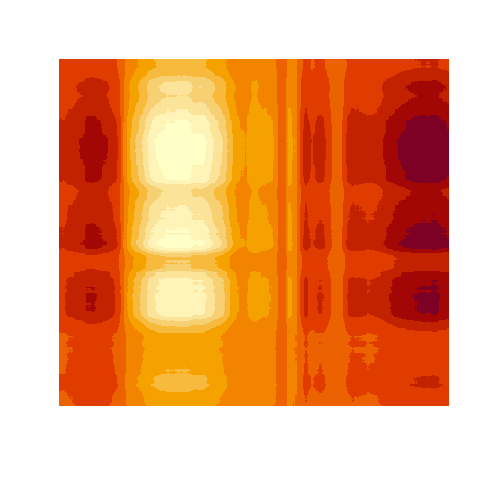

### k = 2

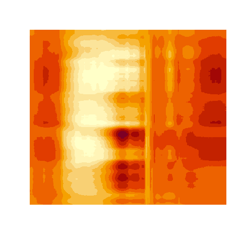

### k = 3

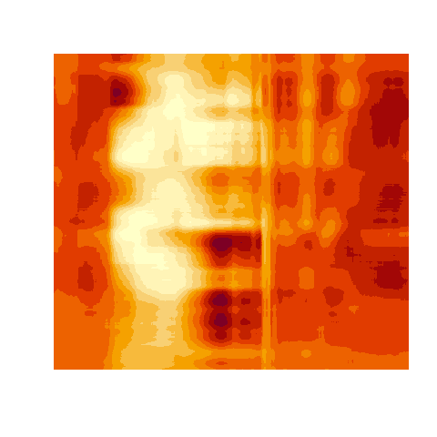

### k = 4

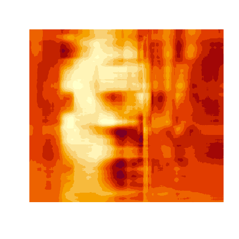

### k = 5

[figure not shown]

### k = 6

[figure not shown]

### k = 7

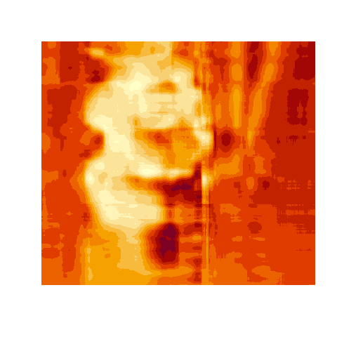

### k = 8

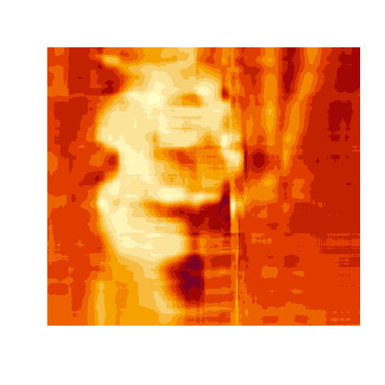

### k = 9

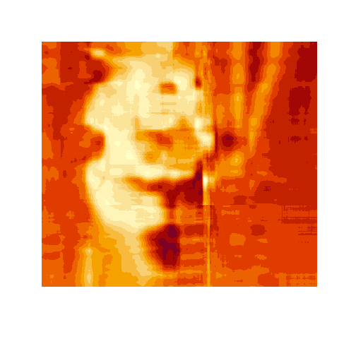

### k = 10

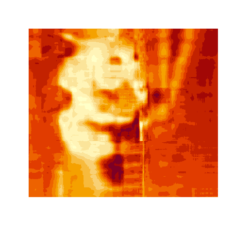

The image looks sufficiently good at k = 10, it captures the shape and shadows of the puppy at that point without extra details.

## K vs. Error plot

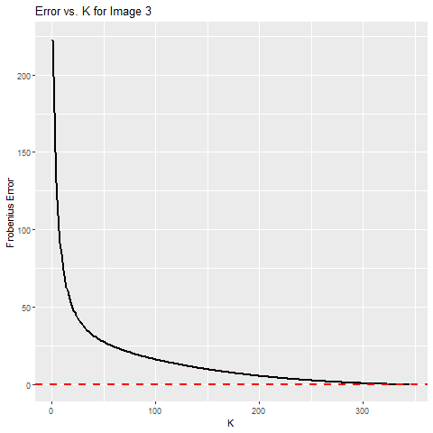

## 1st Eigenvector and PC Score plots

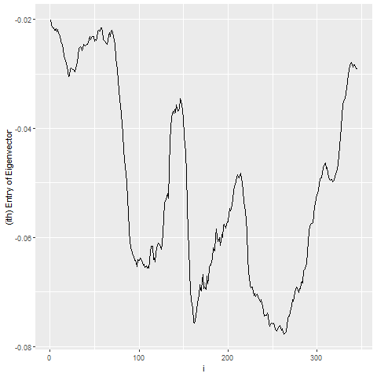

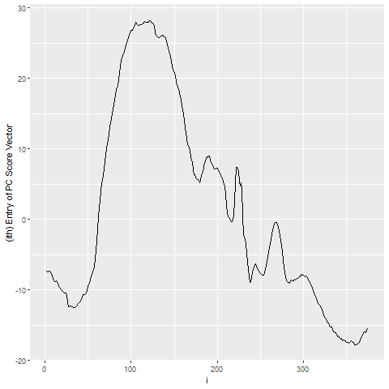

The eigenvector plot shows a series of dips, valleys, and peaks, with heights at the end and dips around the middle of the graph. These varied coefficients are an indication of the complexity of representing the image. The PC plot appears to be an inverse of the eigenvector plot, with one main peak around indices 120, and generally decreasing afterwards.